# Homework 1: Stacking

Data Science 2: Machine Learning Tools - CEU 2021

Abduvosid Malikov

This analysis aims to predict whether patients actually show up for their medical appointments.

### a. Create train / validation / test sets, cutting the data into 5% - 45% - 50% parts.

After some cleaning, dataset consists of 71934 observations and 9 variables. 6 variables are factor variables and 3 variables are numeric variables.

### b. Train a benchmark model of your choice (such as random forest, gbm or glm) and evaluate it on the validation set.

Random forest model was created as a benchmark and trained.

When evaluated on the validation set, AUC of the RF model was equal to 0.6007.

```
## [1] 0.6007072
```

### c. Build at least 3 models of different families using cross validation, keeping cross validated predictions. You might also try deeplearning.

These models were built and trained:

- Random Forest (Ensemble Algorithms);
- GLM (Regression Algorithms);
- GBM (Boosting);
- Deep Learning (Deep Learning Algorithms, Artificial Neural Network Algorithms)

### d. Evaluate validation set performance of each model.

| glm | rf | gbm | deeplearning |
| --- | --- | --- | --- |
| 0.5836 | 0.6007 | 0.6025 | 0.5992 |

### e. How large are the correlations of predicted scores of the validation set produced by the base learners?

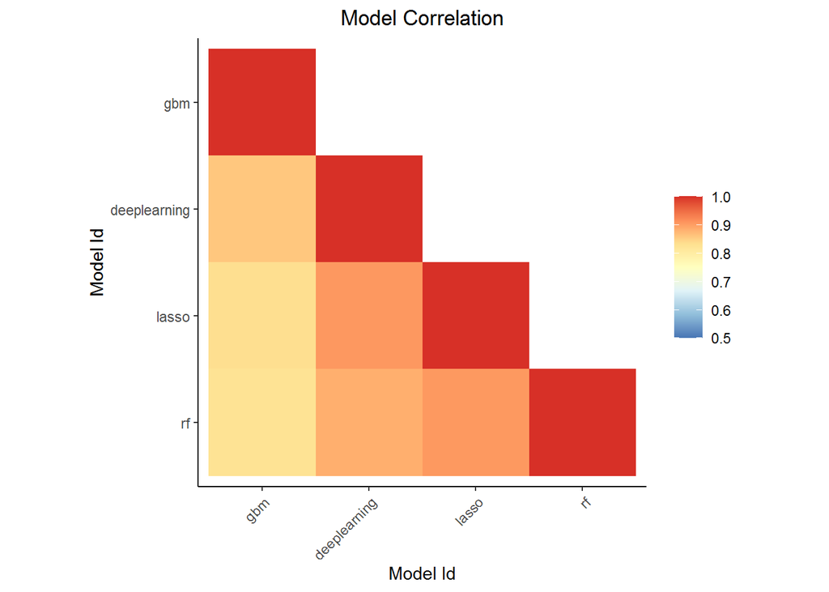

This heatmap allows us to see the correlation of predicted scores of the validation set produced by the base learners.

In general, we can see that all the predicted scores are highly correlated.

Highest correlation belongs to RF and GLM (lasso).

Correlation between predicted score of RF and deep learning is also high.

### f. Create a stacked ensemble model from the base learners.

| names | coefficients | standardized_coefficients |
| --- | --- | --- |
| Intercept | -2.4227 | -0.9374 |
| lasso | 0.4000 | 0.0207 |
| rf | 2.4411 | 0.1551 |
| gbm | 1.8236 | 0.1423 |
| deeplearning | 0.5551 | 0.0452 |

Here we can see the coefficients generated by the stacked model for each learner.

### g. Evaluate ensembles on validation set. Did it improve prediction?

```
## [1] 0.6039646
```

### h. Evaluate the best performing model on the test set. How does performance compare to that of the validation set?

```
## [1] 0.5977137
```